# 705604096_stats101c_hw4

Jade Gregory

2023-10-30

## Question 1

```r
kagtrain <- read.csv("TrainSAData2.csv")
kagtest <- read.csv("TestSAData2NoY.csv")
head(kagtrain)
```

```
##   ID    sex age height weight waistline sight_left sight_right hear_left
## 1  1   Male  75    160     NA        NA         NA         0.7    Normal
## 2  2 Female  50    160     60      74.0        1.0         1.2    Normal
## 3  3   Male  65    170     80      95.0        1.0         1.5    Normal
## 4  4   <NA>  65    155     55      81.0        0.3         0.4  Abnormal
## 5  5   Male  35    160     60      85.0        1.0         1.0    Normal
## 6  6 Female  50    160     70      73.2        0.3         0.4    Normal
##   hear_right SBP DBP BLDS tot_chole HDL_chole LDL_chole triglyceride hemoglobin
## 1     Normal  NA  76  136       215        33       143          193       15.0
## 2     Normal 118  70  125       207        85        NA          110       13.3
## 3     Normal 149  83  130       115        48        33          170       16.4
## 4   Abnormal 118  67   97       171        65        67          195       13.9
## 5     Normal  96  62   78       114        42        58           72       16.0
## 6     Normal 119  79  220       178        61        80          181       10.5
##   urine_protein serum_creatinine SGOT_AST SGOT_ALT gamma_GTP      BMI
## 1             3              0.9       28       23        36 23.43750
## 2             1              0.6       28       19        22 23.43750
## 3             1              1.4       41       64        53       NA
## 4             1              0.8       26       25        NA 22.89282
## 5             1              1.0       17       24        34       NA
## 6             1              0.5       36       NA        20 27.34375
##   BMI.Category AGE.Category Smoking.Status Alcoholic.Status
## 1      Healthy     Very Old  Still Smoking                Y
## 2         <NA>     Mid-aged   Never Smoked                Y
## 3   Overweight          Old  Still Smoking                Y
## 4         <NA>          Old   Never Smoked                N
## 5      Healthy     Mid-aged  Still Smoking                N
## 6   Overweight     Mid-aged   Never Smoked                N
```

```r
head(kagtest)
```

```
##   ID    sex age height weight waistline sight_left sight_right hear_left
## 1  1   <NA>  40    175     NA        76        1.5         1.2    Normal
## 2  2 Female  55    150     55        81        1.0         0.9    Normal
## 3  3 Female  35    155     50        73        0.2         0.2    Normal
## 4  4 Female  60    155     50        79        1.0         1.0    Normal
## 5  5   Male  55    165     65        84         NA         0.9    Normal
## 6  6   Male  45    170     55        73        1.5         1.2    Normal
##   hear_right SBP DBP BLDS tot_chole HDL_chole LDL_chole triglyceride hemoglobin
## 1     Normal 118  78   89       160        49        75          181         NA
## 2     Normal  89  52  109       240        67       154           95       12.6
## 3     Normal 102  63   86        NA        48       120           63       12.0
## 4     Normal  NA  76   97       222        61       140          101       12.9
## 5     Normal 102  63   NA       198        46       112          200       17.1
## 6     Normal 120  80   98       152        NA        55          283       14.5
##   urine_protein serum_creatinine SGOT_AST SGOT_ALT gamma_GTP      BMI
## 1             1              1.1       18       13        15 22.85714
## 2             1              0.7       47       32        27 24.44444
## 3             1              0.8       14       10        10 20.81165
## 4             1              1.0       33       NA        64 20.81165
## 5             2              0.7       21       33        78 23.87511
## 6             1              1.0       17       25        26       NA
##   BMI.Category AGE.Category Smoking.Status
## 1      Healthy     Mid-aged  Still Smoking
## 2         <NA>          Old           <NA>
## 3      Healthy     Mid-aged           <NA>
## 4      Healthy          Old   Never Smoked
## 5      Healthy          Old   Never Smoked
## 6      Healthy     Mid-aged  Still Smoking
```

```r
dim(kagtrain)
```

```
## [1] 70000    28
```

```r
dim(kagtest)
```

```
## [1] 30000    27
```

The training data set has 28 columns by 70,000 rows. The testing data set has 27 columns by 30,000 rows.

2. There are 21 numerical predictors. They include the variables ID, age, height, weight, waistline, sight_left, sight_right, SBP, DBP, BLDS, tot_chole, HDL_chole, LDL_chole, triglyceride, hemoglobin, urine_protein, serum_creatinine, SGOT_AST, SGOT_ALT, gamma_GTP, and BMI.
3. There are 7 categorical variables. They are sex, hear_left, hear_right, BMI.Category, AGE.Category, Smoking.Status, and Alcoholic.Status.

```r
(sapply(kagtrain, function(x) sum(is.na(x))) / 70000) * 100
```

```
##               ID              sex              age           height
##         0.000000         7.088571         6.967143         7.058571
##           weight        waistline       sight_left      sight_right
##         7.102857         7.057143         6.967143         7.000000
##        hear_left       hear_right              SBP              DBP
##         6.904286         6.981429         7.027143         6.992857
##             BLDS        tot_chole        HDL_chole        LDL_chole
##         6.887143         6.948571         6.880000         7.020000
##     triglyceride       hemoglobin    urine_protein serum_creatinine
##         6.967143         7.087143         6.998571         6.924286
##         SGOT_AST         SGOT_ALT        gamma_GTP              BMI
##         6.981429         6.990000         7.087143         7.095714
##     BMI.Category     AGE.Category   Smoking.Status Alcoholic.Status
##         6.962857        11.875714         6.970000         0.000000
```

```r
((sapply(kagtest, function(x) sum(is.na(x)))) / 30000) * 100
```

```
##               ID              sex              age           height
##         0.000000         7.296667         7.103333         7.063333
##           weight        waistline       sight_left      sight_right
##         7.003333         7.183333         6.736667         7.146667
##        hear_left       hear_right              SBP              DBP
##         6.840000         6.800000         7.013333         7.056667
##             BLDS        tot_chole        HDL_chole        LDL_chole
##         7.050000         7.203333         7.026667         7.003333
##     triglyceride       hemoglobin    urine_protein serum_creatinine
##         6.680000         6.896667         6.830000         6.953333
##         SGOT_AST         SGOT_ALT        gamma_GTP              BMI
##         6.933333         7.076667         6.853333         7.200000
##     BMI.Category     AGE.Category   Smoking.Status
##         7.073333        11.730000         7.030000
```

```r
length(kagtrain$Alcoholic.Status[kagtrain$Alcoholic.Status == "Y"])
```

```
## [1] 34887
```

```r
length(kagtrain$Alcoholic.Status[kagtrain$Alcoholic.Status == "N"])
```

```
## [1] 35113
```

Our response variable is Alcoholic.Status that has two values, yes or no, denotes Y or N. Alcoholic.Status is Y 34887 times out of 70000 observations which is 49.84% and it is N 35113 times out of 70000 observations which is 50.16%. Our max error rate based on our training data is 49.84%.

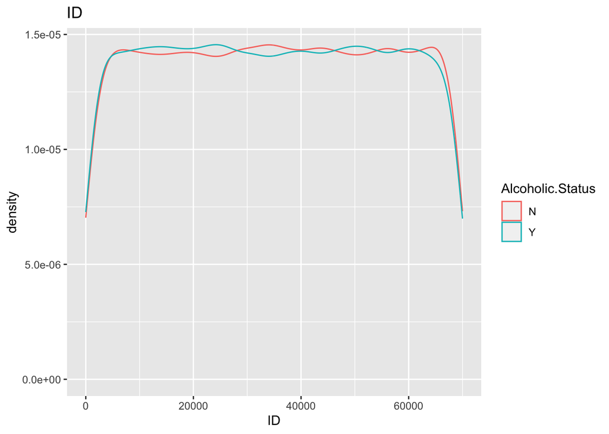

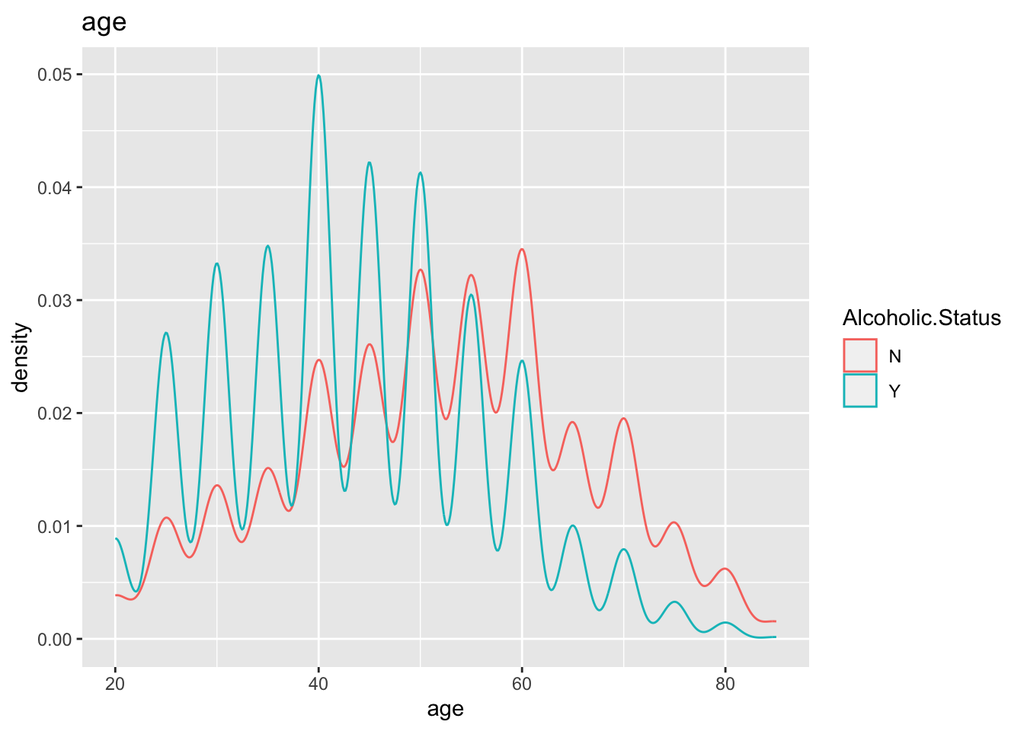

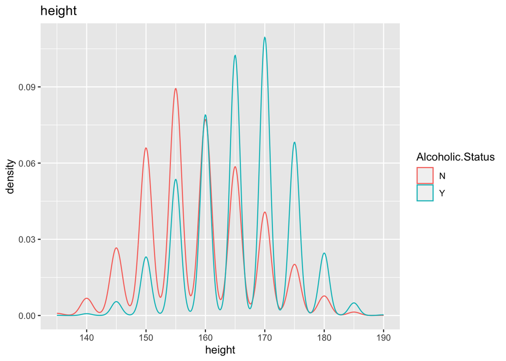

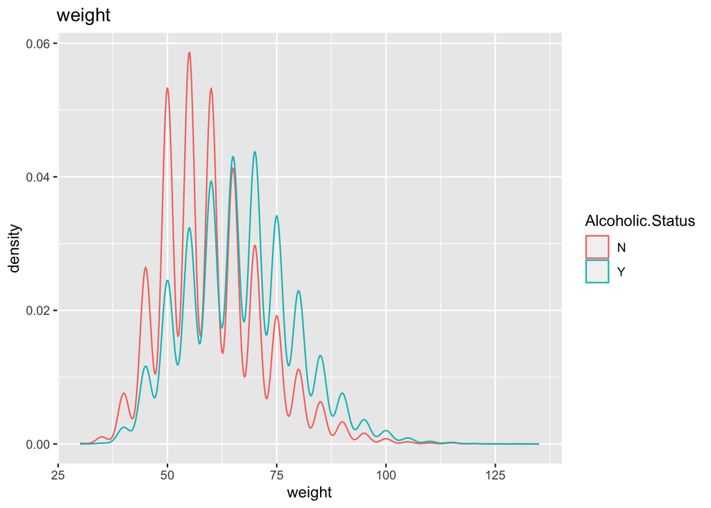

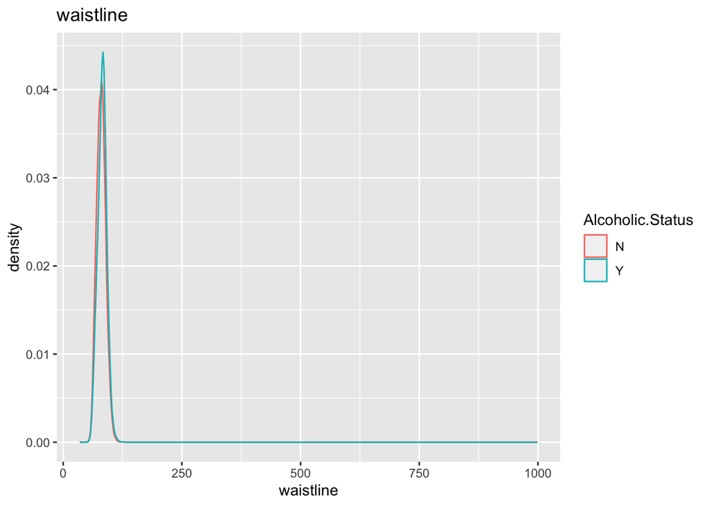

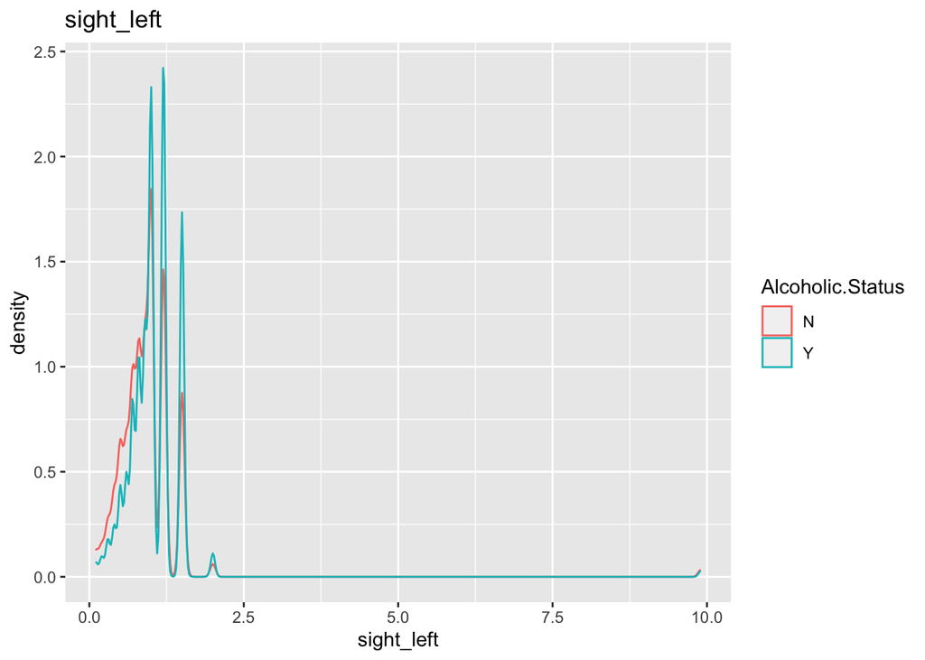

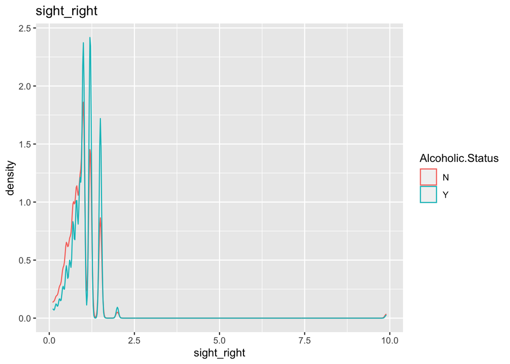

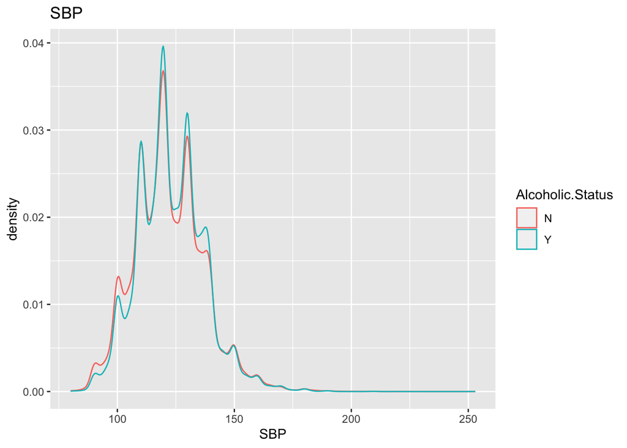

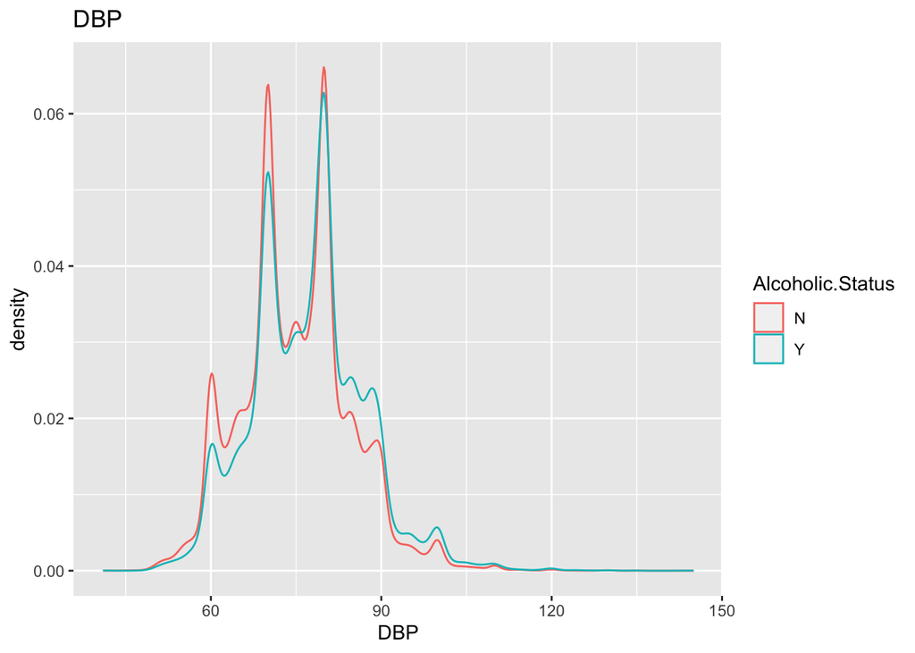

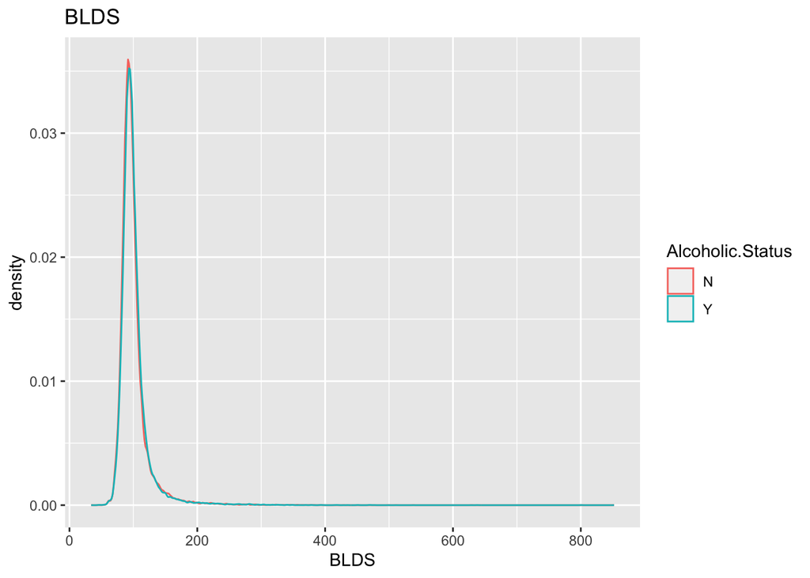

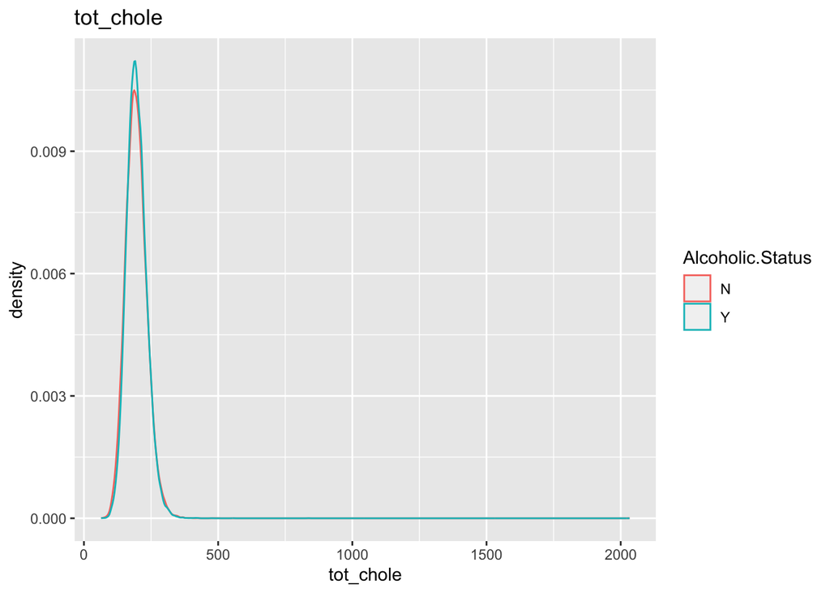

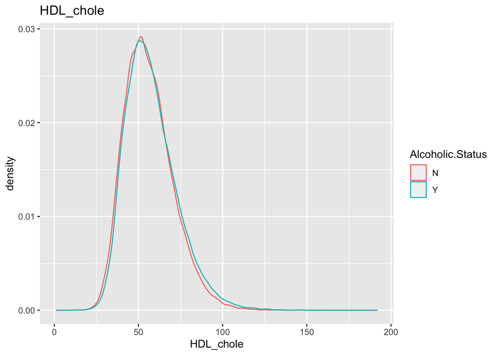

[9 more figures not shown]

```r
num_names <- names(kagtrain[sapply(kagtrain, is.numeric)])
for(variable in num_names){
  plot <- ggplot(kagtrain, aes_string(variable, color = "Alcoholic.Status")) + geom_density() + ggtitle(variable)
  print(plot)
}
```

The best four numerical predictors are age, height, hemoglobin and BMI. We can infer this information from their density charts.

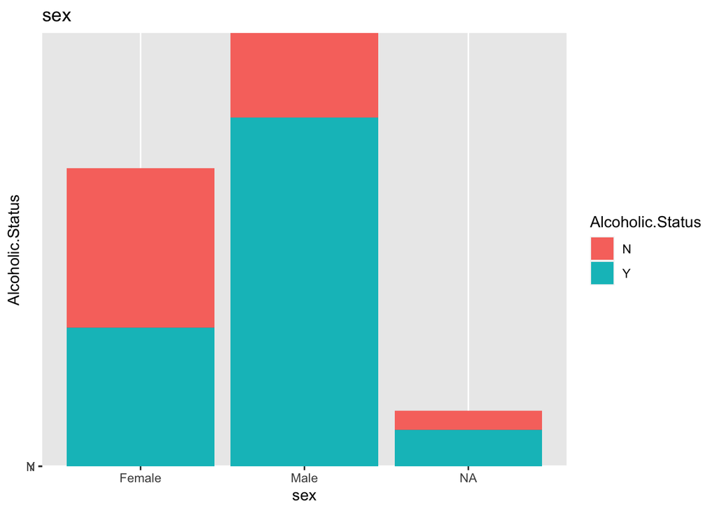

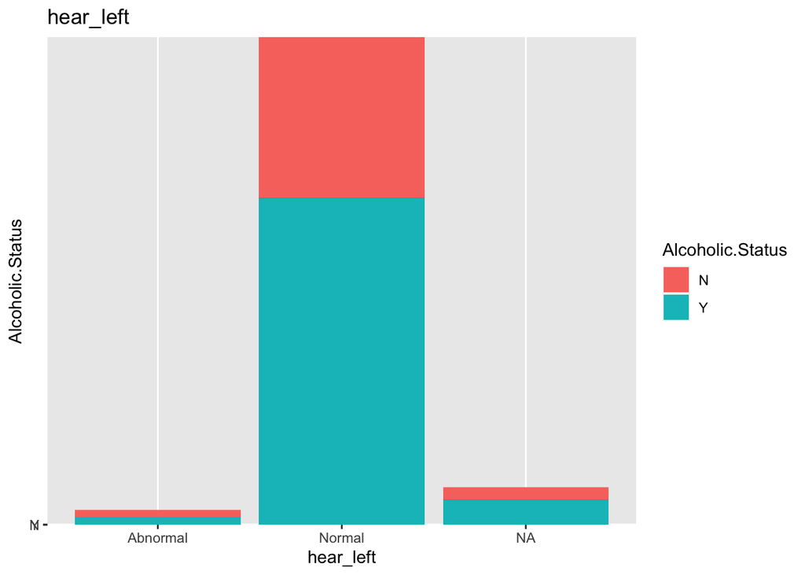

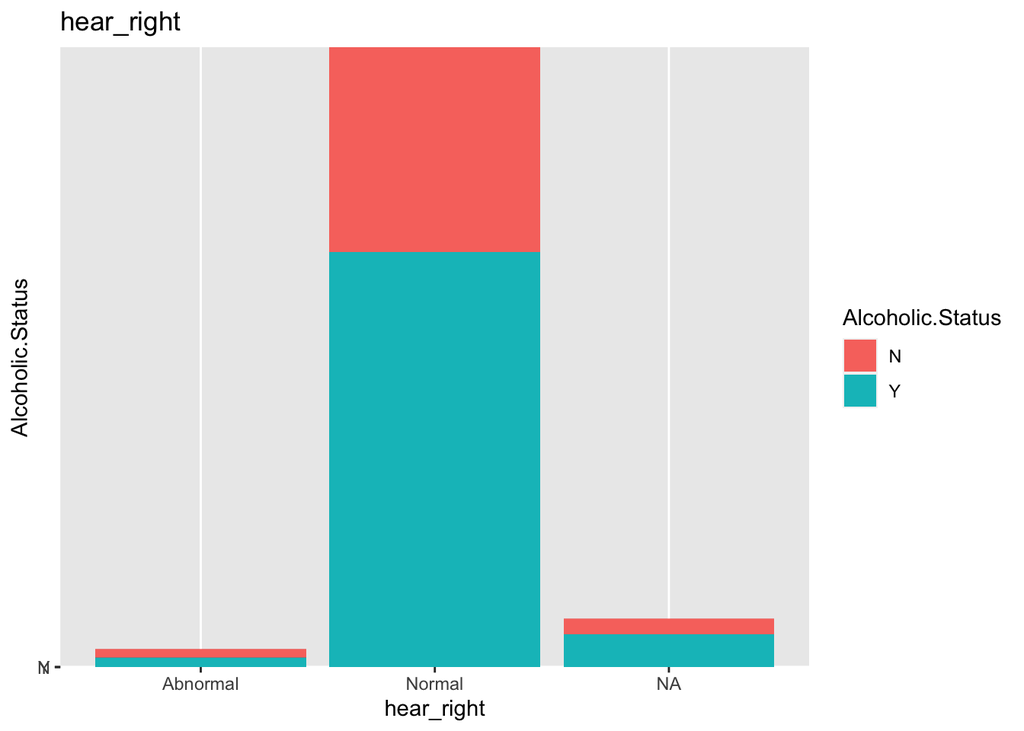

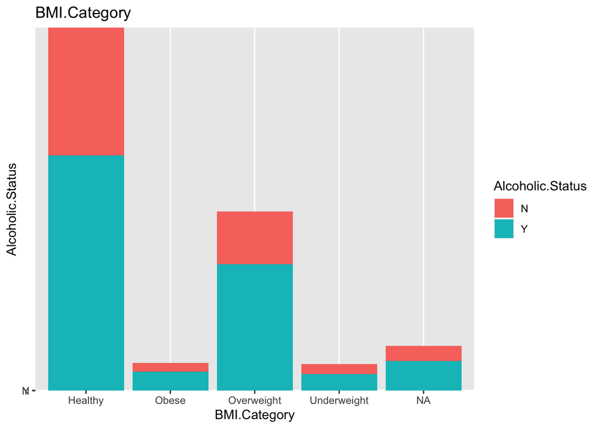

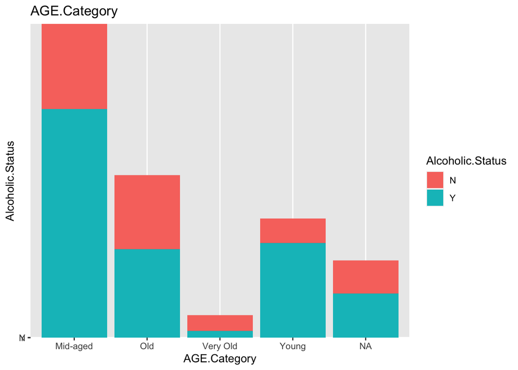

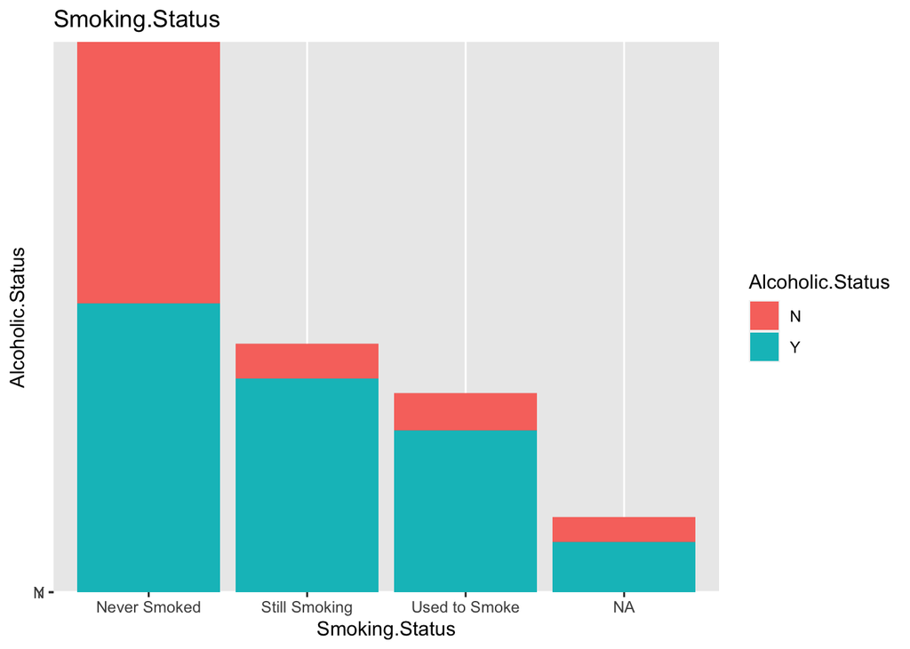

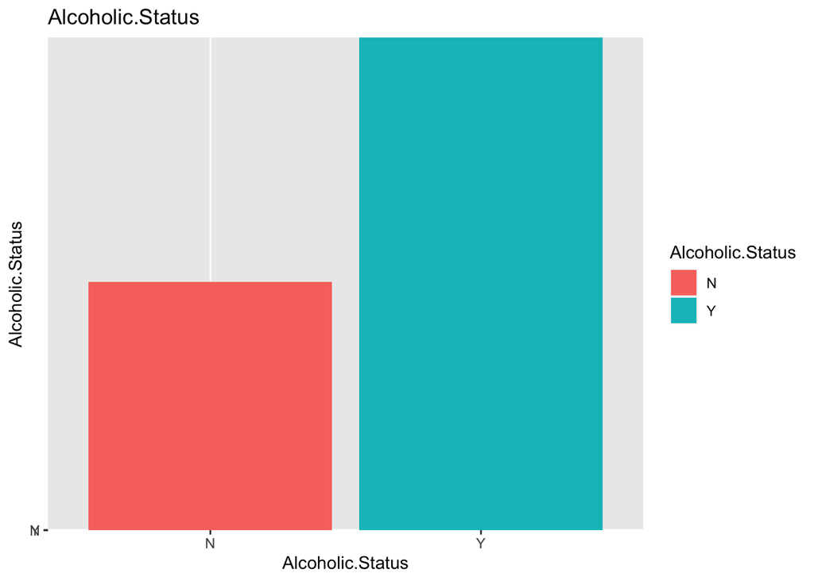

```r
cat_names <- names(kagtrain[sapply(kagtrain, is.character)])
for(variable in cat_names){
  plot <- ggplot(kagtrain, aes_string(fill = "Alcoholic.Status", y = "Alcoholic.Status", x = variable)) + geom_bar(position = "stack", stat = "identity") + ggtitle(variable)
  print(plot)
}
```

Our best two categorical predictor variables are Smoking.Status and AGE.Category.

## Question 2

```r
head(kagtrain %>% mutate(across(where(is.numeric), ~replace_na(., median(., na.rm = TRUE)))))
```

```
##   ID    sex age height weight waistline sight_left sight_right hear_left
## 1  1   Male  75    160     60      81.0        1.0         0.7    Normal
## 2  2 Female  50    160     60      74.0        1.0         1.2    Normal
## 3  3   Male  65    170     80      95.0        1.0         1.5    Normal
## 4  4   <NA>  65    155     55      81.0        0.3         0.4  Abnormal
## 5  5   Male  35    160     60      85.0        1.0         1.0    Normal
## 6  6 Female  50    160     70      73.2        0.3         0.4    Normal
##   hear_right SBP DBP BLDS tot_chole HDL_chole LDL_chole triglyceride hemoglobin
## 1     Normal 120  76  136       215        33       143          193       15.0
## 2     Normal 118  70  125       207        85       111          110       13.3
## 3     Normal 149  83  130       115        48        33          170       16.4
## 4   Abnormal 118  67   97       171        65        67          195       13.9
## 5     Normal  96  62   78       114        42        58           72       16.0
## 6     Normal 119  79  220       178        61        80          181       10.5
##   urine_protein serum_creatinine SGOT_AST SGOT_ALT gamma_GTP      BMI
## 1             3              0.9       28       23        36 23.43750
## 2             1              0.6       28       19        22 23.43750
## 3             1              1.4       41       64        53 23.87511
## 4             1              0.8       26       25        23 22.89282
## 5             1              1.0       17       24        34 23.87511
## 6             1              0.5       36       20        20 27.34375
##   BMI.Category AGE.Category Smoking.Status Alcoholic.Status
## 1      Healthy     Very Old  Still Smoking                Y
## 2         <NA>     Mid-aged   Never Smoked                Y
## 3   Overweight          Old  Still Smoking                Y
## 4         <NA>          Old   Never Smoked                N
## 5      Healthy     Mid-aged  Still Smoking                N
## 6   Overweight     Mid-aged   Never Smoked                N
```

```r
kagtrain$sex <- as.factor(kagtrain$sex)
kagtrain$hear_left <- as.factor(kagtrain$hear_left)
kagtrain$hear_right <- as.factor(kagtrain$hear_right)
kagtrain$BMI.Category <- as.factor(kagtrain$BMI.Category)
kagtrain$AGE.Category <- as.factor(kagtrain$AGE.Category)
kagtrain$Smoking.Status <- as.factor(kagtrain$Smoking.Status)
kagtrain$Alcoholic.Status <- as.factor(kagtrain$Alcoholic.Status)
cleankagtrain <- kagtrain[complete.cases(kagtrain), ]
cleankagtrain$Alcoholic.Status <- as.factor(cleankagtrain$Alcoholic.Status)
```

```r
glmkag <- glm(Alcoholic.Status ~ . - ID - Alcoholic.Status, data = cleankagtrain, family = binomial())
summary(glmkag)
```

```
##
## Call:
## glm(formula = Alcoholic.Status ~ . - ID - Alcoholic.Status, family = binomial(),
##     data = cleankagtrain)
##
## Coefficients:
##                               Estimate Std. Error z value Pr(>|z|)
## (Intercept)                 -3.9771959  3.2391986  -1.228  0.21951
## sexMale                      1.0663028  0.0945390  11.279  < 2e-16 ***
## age                         -0.0379901  0.0052914  -7.180 6.99e-13 ***
## height                       0.0108923  0.0197531   0.551  0.58135
## weight                       0.0073973  0.0245745   0.301  0.76340
## waistline                   -0.0005591  0.0020247  -0.276  0.78242
## sight_left                   0.0134764  0.0485802   0.277  0.78147
## sight_right                 -0.0247307  0.0453646  -0.545  0.58565
## hear_leftNormal             -0.0928936  0.1769397  -0.525  0.59958
## hear_rightNormal             0.0594782  0.1846674   0.322  0.74739
## SBP                          0.0025443  0.0026671   0.954  0.34011
## DBP                          0.0118107  0.0037365   3.161  0.00157 **
## BLDS                         0.0001888  0.0010225   0.185  0.85354
## tot_chole                    0.0004400  0.0043060   0.102  0.91861
## HDL_chole                    0.0230691  0.0044950   5.132 2.86e-07 ***
## LDL_chole                   -0.0019803  0.0043409  -0.456  0.64825
## triglyceride                 0.0008135  0.0007352   1.107  0.26849
## hemoglobin                  -0.0044983  0.0211150  -0.213  0.83130
## urine_protein               -0.0437604  0.0548591  -0.798  0.42505
## serum_creatinine            -0.3112565  0.1164993  -2.672  0.00755 **
## SGOT_AST                     0.0196459  0.0034722   5.658 1.53e-08 ***
## SGOT_ALT                    -0.0249463  0.0023168 -10.768  < 2e-16 ***
## gamma_GTP                    0.0134537  0.0010989  12.243  < 2e-16 ***
## BMI                          0.0154784  0.0660724   0.234  0.81478
## BMI.CategoryObese           -0.5100170  0.1930533  -2.642  0.00825 **
## BMI.CategoryOverweight      -0.0727624  0.0886899  -0.820  0.41198
## BMI.CategoryUnderweight     -0.0980623  0.1306307  -0.751  0.45284
## AGE.CategoryOld             -0.1812045  0.0966219  -1.875  0.06074 .
## AGE.CategoryVery Old        -0.4333644  0.2273759  -1.906  0.05666 .
## AGE.CategoryYoung            0.0412159  0.1071919   0.385  0.70060
## Smoking.StatusStill Smoking  0.8290526  0.0711244  11.656  < 2e-16 ***
## Smoking.StatusUsed to Smoke  0.8717824  0.0725326  12.019  < 2e-16 ***
## ---
## Signif. codes:  0 '***' 0.001 '**' 0.01 '*' 0.05 '.' 0.1 ' ' 1
##
## (Dispersion parameter for binomial family taken to be 1)
##
##     Null deviance: 13906  on 10032  degrees of freedom
## Residual deviance: 10852  on 10001  degrees of freedom
## AIC: 10916
##
## Number of Fisher Scoring iterations: 5
```

```r
kagprob <- predict(glmkag, data = cleankagtrain, type = "response")
kagpredlog <- rep("Y", length(kagprob))
kagpredlog[kagprob <= 0.5] <- "N"
table(kagpredlog, cleankagtrain$Alcoholic.Status)
```

```
##
## kagpredlog    N    Y
##          N 3577 1371
##          Y 1364 3721
```

```r
mean(kagpredlog != cleankagtrain$Alcoholic.Status)
```

```
## [1] 0.2726004
```

The misclassification rate is 27.26%.

```r
kptest <- predict(glmkag, data = cleankagtrain, newdata = kagtest, type = "response")
kgtestpl <- rep("Y", length(kptest))
kgtestpl[kptest <= 0.5] <- "N"
my_kaggle <- data.frame(ID = 1:nrow(kagtest), predictions = kgtestpl)
write.csv(my_kaggle, file = "kagglepredictions.csv", row.names = FALSE)
```

My kaggle public score is 0.52996.

4. My kaggle rank is 64th.

## Question 3

```r
winetrain <- read.csv("WineTrain copy.csv")
winetest <- read.csv("WineTest copy.csv")
winetrain$Class <- as.factor(winetrain$Class)
winetrain$Wine.Color <- as.factor(winetrain$Wine.Color)
winetest$Class <- as.factor(winetest$Class)
winetest$Wine.Color <- as.factor(winetest$Wine.Color)
winedat <- rbind(winetrain, winetest)
head(winedat)
```

```
##   X Wine.Color fixed.acidity volatile.acidity citric.acid residual.sugar
## 1 1          W           7.3             0.23        0.41           14.6
## 2 2          R          10.0             0.32        0.59            2.2
## 3 3          W           6.2             0.27        0.43            7.8
## 4 4          W           6.6             0.25        0.32            5.6
## 5 5          W           6.9             0.24        0.39            1.3
## 6 6          W           7.1             0.23        0.39            1.6
##   chlorides free.sulfur.dioxide total.sulfur.dioxide density   pH sulphates
## 1     0.048                  73                  223 0.99863 3.16      0.71
## 2     0.077                   3                   15 0.99940 3.20      0.78
## 3     0.056                  48                  244 0.99560 3.10      0.51
## 4     0.039                  15                   68 0.99163 2.96      0.52
## 5     0.063                  18                  136 0.99280 3.31      0.48
## 6     0.032                  12                   65 0.98980 3.25      0.40
##   alcohol Class
## 1     9.4   Bad
## 2     9.6   Bad
## 3     9.0   Bad
## 4    11.1  Good
## 5    10.4  Good
## 6    12.7  Good
```

```r
dim(winedat)
```

```
## [1] 4000   14
```

```r
library(crossval)
library(boot)
# logistic regression
wineglm <- glm(Class ~ . - X - Class, data = winedat, family = binomial())
wineprob <- predict(wineglm, data = winedat, type = "response")
winepredl <- rep("Good", length(wineprob))
winepredl[wineprob <= 0.5] <- "Bad"
table(winepredl, winedat$Class)
```

```
##
## winepredl  Bad Good
##      Bad  1374  755
##      Good  676 1195
```

```r
mean(winepredl != winedat$Class)
```

```
## [1] 0.35775
```

We can see our confusion matrix in our output above. Our misclassification rate for this model is 35.775%.

```r
# lda model
winelda <- lda(Class ~ . - X - Class, data = winedat, CV = TRUE)
summary(winelda)
```

```
##           Length Class  Mode
## class     4000   factor numeric
## posterior 8000   -none- numeric
## terms        3   terms  call
## call         4   -none- call
## xlevels      1   -none- list
```

```r
table(winelda$class, winedat$Class)
```

```
##
##         Bad Good
##   Bad  1374  771
##   Good  676 1179
```

```r
mean(winelda$class != winedat$Class)
```

```
## [1] 0.36175
```

Our misclassification rate is 36.175%.

```r
# qda model
wineqda <- qda(Class ~ . - X - Class, data = winedat, CV = TRUE)
summary(wineqda)
```

```
##           Length Class  Mode
## class     4000   factor numeric
## posterior 8000   -none- numeric
## terms        3   terms  call
## call         4   -none- call
## xlevels      1   -none- list
```

```r
table(wineqda$class, winedat$Class)
```

```
##
##         Bad Good
##   Bad  1058  499
##   Good  992 1451
```

```r
mean(wineqda$class != winedat$Class)
```

```
## [1] 0.37275
```

Our misclassification rate for our qda model of the wine data is 37.275%.

```r
# knn model with k = 25
wine_knn1 <- train(as.factor(Class) ~ . - X, data = winedat, method = "knn", trControl = trainControl(method = "LOOCV", number = 10), tuneGrid = data.frame(k = 25))
```

## Question 4

```r
# logistic regression with 10 fold method
wineglm10f <- cv.glm(winedat, wineglm, K = 10)
summary(wineglm10f)
```

```
##       Length Class  Mode
## call    4    -none- call
## K       1    -none- numeric
## delta   2    -none- numeric
## seed  626    -none- numeric
```

```r
cv.err.10 <- wineglm10f$delta
cv.err.10
```

```
## [1] 0.2267839 0.2267017
```

```r
wine_lda <- train(as.factor(Class) ~ . - X, data = winedat, method = "lda", trControl = trainControl(method = "cv", number = 10))
caret::confusionMatrix(wine_lda)
```

```
## Cross-Validated (10 fold) Confusion Matrix
##
## (entries are percentual average cell counts across resamples)
##
##           Reference
## Prediction  Bad Good
##       Bad  34.5 19.1
##       Good 16.8 29.6
##
##  Accuracy (average) : 0.6408
```

```r
wine_qda <- train(as.factor(Class) ~ . - X, data = winedat, method = "qda", trControl = trainControl(method = "cv", number = 10))
caret::confusionMatrix(wine_qda)
```

```
## Cross-Validated (10 fold) Confusion Matrix
##
## (entries are percentual average cell counts across resamples)
##
##           Reference
## Prediction  Bad Good
##       Bad  26.4 12.6
##       Good 24.9 36.2
##
##  Accuracy (average) : 0.6255
```

```r
wine_knn <- train(as.factor(Class) ~ . - X, data = winedat, method = "knn", trControl = trainControl(method = "cv", number = 10), tuneGrid = data.frame(k = 25))
caret::confusionMatrix(wine_knn)
```

```
## Cross-Validated (10 fold) Confusion Matrix
##
## (entries are percentual average cell counts across resamples)
##
##           Reference
## Prediction  Bad Good
##       Bad  32.2 22.2
##       Good 19.0 26.6
##
##  Accuracy (average) : 0.5875
```